# **Panorama da inflação**

# IPCA

O Indíce de Preços ao Consumidor Amplo (IPCA) variou 0.86% em janeiro, valor superior ao mesmo período do ano anterior quando apresentou uma taxa de 0.56%. Com esse resultado o indíce acumula no ano uma variação positiva de 0.86%, e em 12 meses uma variação positiva de 6.15%.

|  | 01/2012 | 12/2012 | 01/2013 |
| --- | --- | --- | --- |
| Variação mensal | 0.56% | 0.79% | 0.86% |
| Variação acumulada no ano | 0.56% | 5.84% | 0.86% |
| Variação acumulada em 12 meses | 6.22% | 5.84% | 6.15% |

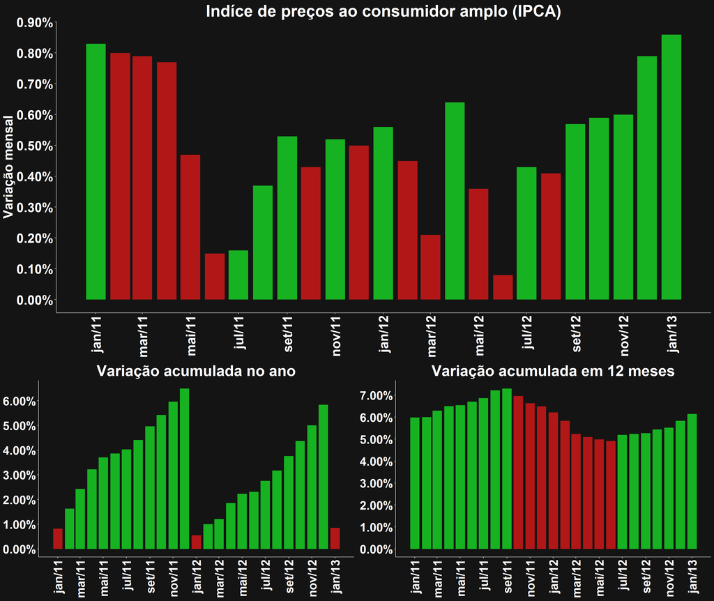

Os grupos que tiveram maior resultado positivo foram Alimentação e bebidas (1.99%) e Despesas pessoais (1.55%), e negativo Vestuário (-0.53%) e Habitação (-0.2%).

|  | Variação mensal | Variação acumulada no ano | Peso mensal |
| --- | --- | --- | --- |
| Alimentação e bebidas | 1.99% | 1.99% | 23.98% |
| Habitação | -0.2% | -0.2% | 14.75% |
| Artigos de residência | 1.15% | 1.15% | 4.45% |
| Vestuário | -0.53% | -0.53% | 6.66% |
| Transportes | 0.75% | 0.75% | 19.52% |
| Saúde e cuidados pessoais | 0.73% | 0.73% | 11.11% |
| Despesas pessoais | 1.55% | 1.55% | 10.35% |
| Educação | 0.35% | 0.35% | 4.45% |
| Comunicação | -0.08% | -0.08% | 4.73% |

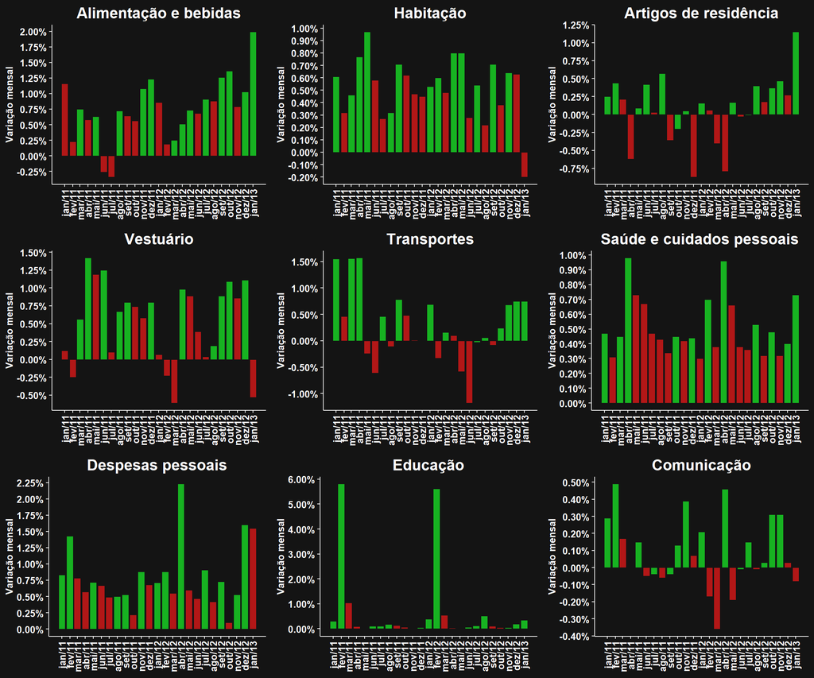

A nível de sub-itens os que mais influenciaram positivamente no resultado em relação ao seu peso foram Cigarro (10.11%%) e Aluguel residencial (1.56%%), e negativamente Energia elétrica residencial (-3.91%%) e Calça comprida feminina (-2.03%%).

|  | Variação mensal | Variação acumulada no ano | Peso mensal |
| --- | --- | --- | --- |
| Tomate | 26.15% | 26.15% | 0.22% |
| Cigarro | 10.11% | 10.11% | 0.93% |
| Aluguel residencial | 1.56% | 1.56% | 3.81% |
| Automóvel novo | 1.41% | 1.41% | 3.22% |

|  | Variação mensal | Variação acumulada no ano | Peso mensal |
| --- | --- | --- | --- |
| Blusa | -1.42% | -1.42% | 0.74% |
| Calça comprida masculina | -1.78% | -1.78% | 0.49% |
| Calça comprida feminina | -2.03% | -2.03% | 0.53% |
| Energia elétrica residencial | -3.91% | -3.91% | 3.33% |

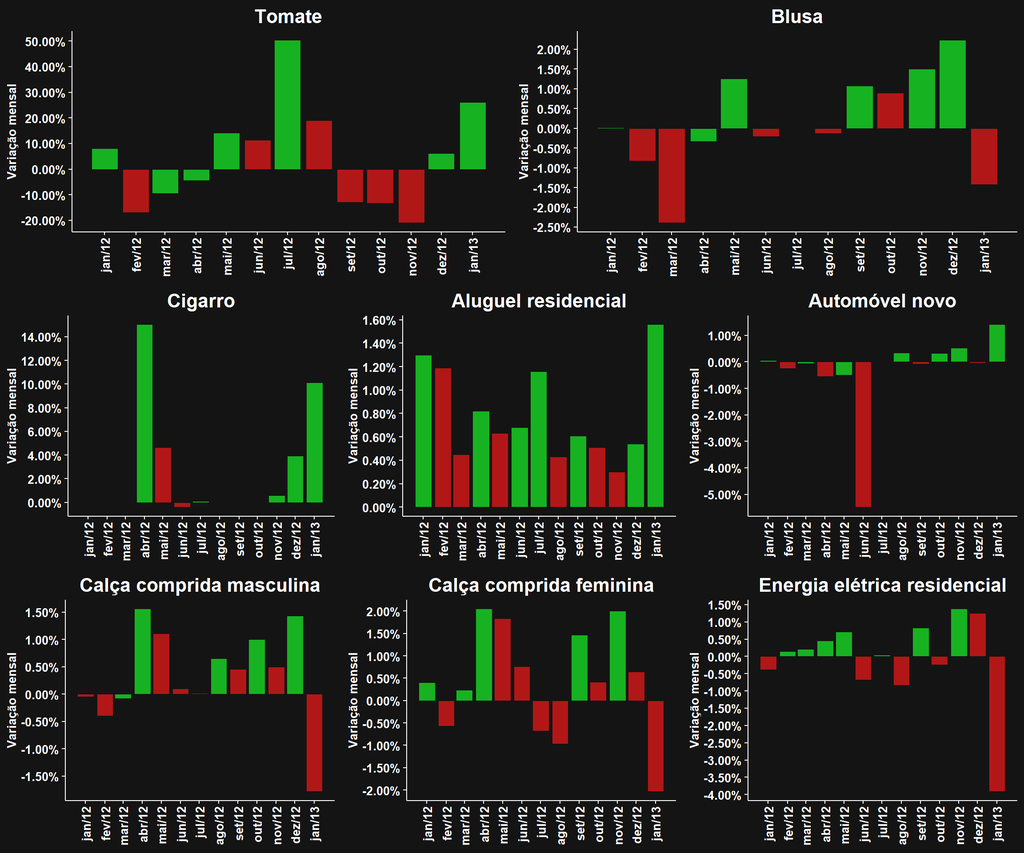